# H07 Stage 2: implementation, diagnostics, and V0 comparison

Nature Health analysis audit — author result and production gate

Published

August 12, 2026

# Result at the Stage 2 gate

The signed hypothesis is:

> **H7: There is a ceiling (nonlinear) effect of absolute latitude and photoperiod on level-, duration-, and exposure-history-based light metrics.**

**NoteAnswer in brief**

Under the owner-revised pointwise derivative rule, six of nine primary near-eye metrics show a derivative-defined plateau pattern: mean melEDI, brightest and darkest 10 h means, time above 1,000 lx melEDI, time above 250 lx melEDI during wake, and melEDI dose. The six transition brackets range from 14.24–14.35 h to 16.10–16.20 h. Time below 10 lx melEDI before sleep and time below 1 lx melEDI during sleep have no earlier pointwise detected increase; the derivative for longest continuous period above 250 lx melEDI remains pointwise positive at the recorded upper boundary.

Seven of nine complementary chest metrics meet the same rule, with transitions bracketed from 13.01–13.11 h to 18.36–18.47 h. Brightest 10 h mean remains pointwise positive at the recorded upper boundary, and time below 10 lx melEDI before sleep has no earlier detected increase.

These are post-result, descriptive classifications from unadjusted pointwise 95% intervals. They show a visible pooled GAM-derivative pattern; they do not demonstrate equivalence to a zero slope, an asymptote, a mechanistic ceiling, or an association independent of site and collection period.

## METRIC-011 bounded input reconciliation

On 2026-08-12, the sealed numerical-zero normalization in `audit/decisions/l10_numerical_zero_normalization.md` changed eight primary darkest-10-h-mean source cells from the floating-point residue `4.163336342344337e-17` lx to exact zero: three near-eye cells and five chest cells. The H07 reopening was therefore restricted to the L10 mean frames, fits, diagnostics, declared sensitivities, leave-one-site-out checks, and the BH fields in families containing the L10 slot. Historical V0 fits and all non-L10 fits and raw tests remained frozen.

The bounded refit changed no sample count, diagnostic category, derivative classification, transition grid point, conditional-AIC support category, BH significance label, or three-decimal REPORT-008 value. The primary result therefore remains six of nine near-eye and seven of nine chest patterns, with the L10 mean classified as a derivative-defined plateau pattern at both placements. Numerical derivative differences were limited to floating-point roundoff (approximately `10^-15`).

Table 1: Bounded H07 reconciliation after the sealed METRIC-011 numerical-zero normalization

METRIC-011 reconciliation checks

Controlling decision SHA-256: 23b9f70d1d16f7fd3ebbdbc57aaf78c0a701fe1f9d22bd667d926cd320d40797

| Check | Observed | Expected | Status |
| --- | --- | --- | --- |
| PRIMARY CHANGED CELLS | 8 | 8 | PASS |
| PRIMARY NEAR EYE CHANGED CELLS | 3 | 3 | PASS |
| PRIMARY CHEST CHANGED CELLS | 5 | 5 | PASS |
| NON L10 MODEL FRAME FILES | 947 | 947 | PASS |
| NON L10 RAW TABLE CHECKS | 8 | 8 | PASS |
| CLASSIFICATION FIELD CHANGES | 0 | 0 | PASS |
| ADJUSTED THREE DECIMAL CHANGES | 0 | 0 | PASS |
| SCIENTIFIC CONCLUSION CHANGED | FALSE | FALSE | PASS |
| BOUNDED ARTIFACT APPLY | 138 | 138 | PASS |

The durable reconciliation summary, scientific comparison, and exact bounded artifact-update inventory are under `artifacts/12_manifests/H07/`.

## Revised ceiling assessment

After reviewing the original support-gated Stage 2 output, the owner reopened H07-G1, H07-G9, and H07-G13 through decision `H07-002`. The scientific target is now whether a plateau-like photoperiod association is visible in the pooled data despite the known design limitations. The pooled local-support rule, one-hour rule, and leave-one-site-out rule remain diagnostics but no longer mask the derivative curve or determine eligibility.

For each metric and placement, the revised rule evaluates the first derivative of `s(photoperiod_hours)` at 100 points spanning the exact recorded range. A pattern begins when a pointwise detected increase is immediately followed by a point whose 95% interval contains zero and every later point remains compatible with zero through the maximum recorded photoperiod. The transition is reported as the bracket between those two grid points. The primary implementation uses central differences with forward/backward handling at the boundaries, a 0.01 h step, and unconditional covariance where available.

This decision was made after viewing Stage 2 support results and the intervals are neither simultaneous over a curve nor adjusted across nine metrics. Accordingly, the result is called a **derivative-defined plateau pattern**. It is not an equivalence test: failure to detect a non-zero derivative does not show that the slope is practically zero.

The registered latitude–photoperiod tensor remains structurally non-identifiable because absolute latitude is determined by site. The adapted photoperiod smooth has estimated concurvity of 0.9987–0.9989 with the remaining model structure, so its whole-term p-values remain withheld. These limitations do not suppress the requested descriptive pattern, but they prevent an independent, site-general photoperiod or mechanistic interpretation.

## Approved analytical boundary

The owner approved H07 Stage 1 under decision `H07-001`, then amended the ceiling and support gates under `H07-002`. All nine outcomes still enter independently of H01 fitted results, p-values, or historical retention. Near-eye measurements are primary; chest measurements are complementary. Absolute latitude, civil photoperiod, site, participant nested in site, and collection period remain the complete predictor and design boundary. No temperature, weather, holiday, behavioural, clinical, or health-outcome predictor was added.

The **gap-timing-unaware dataset** still passed the general 50%-per-hour and 80%-per-day coverage rules. Its name means that the timing of remaining missing observations was not used for an additional metric-specific adjustment; it does not mean that gaps, missingness, or coverage were ignored. For contrast, the approved main input could be interpreted as a time-sensitive primary metric dataset because its preparation uses the timing of remaining missing observations when relevant. It is called the **primary dataset** from this point onward.

# Implementation

## Exact fitted samples

The nine metrics have metric-specific complete rows. Participant-days equal observations because the analytical unit is one participant-day. The primary near-eye fits contain 139–141 participants, 655–816 participant-days, and all nine sites. The complementary chest fits contain 153–154 participants, 743–902 participant-days, and eight sites; Tübingen has no chest data.

Exact primary and complementary fitted samples

Every metric was fitted independently of H01 results

| Metric | Participants | Participant-days | Observations | Sites | Collection period | Photoperiod range |
| --- | --- | --- | --- | --- | --- | --- |
| Near-eye — primary |  |  |  |  |  |  |
| Mean melEDI | 141 | 816 | 816 | 9 | 2023-08-15 to 2025-10-19 | 10.33–20.52 h |
| Brightest 10 h mean | 141 | 816 | 816 | 9 | 2023-08-15 to 2025-10-19 | 10.33–20.52 h |
| Darkest 10 h mean | 141 | 816 | 816 | 9 | 2023-08-15 to 2025-10-19 | 10.33–20.52 h |
| Time above 1,000 lx melEDI | 141 | 816 | 816 | 9 | 2023-08-15 to 2025-10-19 | 10.33–20.52 h |
| Time above 250 lx melEDI during wake | 141 | 737 | 737 | 9 | 2023-08-15 to 2025-10-19 | 10.33–20.52 h |
| Time below 10 lx melEDI before sleep | 139 | 655 | 655 | 9 | 2023-08-15 to 2025-10-19 | 10.33–20.52 h |
| Time below 1 lx melEDI during sleep | 141 | 778 | 778 | 9 | 2023-08-15 to 2025-10-19 | 10.33–20.52 h |
| Longest continuous period above 250 lx melEDI | 141 | 816 | 816 | 9 | 2023-08-15 to 2025-10-19 | 10.33–20.52 h |
| melEDI dose | 141 | 761 | 761 | 9 | 2023-08-15 to 2025-10-19 | 10.33–20.52 h |
| Chest — complementary |  |  |  |  |  |  |
| Mean melEDI | 154 | 902 | 902 | 8 | 2024-05-14 to 2025-10-19 | 10.33–20.52 h |
| Brightest 10 h mean | 154 | 902 | 902 | 8 | 2024-05-14 to 2025-10-19 | 10.33–20.52 h |
| Darkest 10 h mean | 154 | 902 | 902 | 8 | 2024-05-14 to 2025-10-19 | 10.33–20.52 h |
| Time above 1,000 lx melEDI | 154 | 902 | 902 | 8 | 2024-05-14 to 2025-10-19 | 10.33–20.52 h |
| Time above 250 lx melEDI during wake | 154 | 818 | 818 | 8 | 2024-05-14 to 2025-10-19 | 10.33–20.52 h |
| Time below 10 lx melEDI before sleep | 153 | 743 | 743 | 8 | 2024-05-14 to 2025-10-19 | 10.33–20.52 h |
| Time below 1 lx melEDI during sleep | 154 | 861 | 861 | 8 | 2024-05-14 to 2025-10-19 | 10.33–20.52 h |
| Longest continuous period above 250 lx melEDI | 154 | 902 | 902 | 8 | 2024-05-14 to 2025-10-19 | 10.33–20.52 h |
| melEDI dose | 154 | 851 | 851 | 8 | 2024-05-14 to 2025-10-19 | 10.33–20.52 h |

## Exact model formulas and engine

All 162 main fits used exact `mgcv::gam(method = "REML")` under R 4.6.1. There was no `bam()` fallback and no `discrete` argument. Every fitted model converged according to the optimizer, although diagnostics can and do override that numerical flag. The exact Wilkinson formulas supplied to the model are shown from the persisted formula registry.

```r
exact_model_formulas <- formula_registry |>
  mutate(parsed_formula = lapply(formula, stats::as.formula))

stopifnot(
  all(vapply(
    exact_model_formulas$parsed_formula,
    inherits,
    logical(1),
    what = "formula"
  ))
)

for (index in seq_len(nrow(exact_model_formulas))) {
  cat(
    exact_model_formulas$model_id[[index]],
    ": ",
    paste(deparse(exact_model_formulas$parsed_formula[[index]]), collapse = " "),
    "\n",
    sep = ""
  )
}
```

```
registered_null: response_value ~ s(site, bs = "re") + s(site_participant, bs = "re")
registered_linear_surface: response_value ~ abs_latitude_deg * photoperiod_hours + s(site,      bs = "re") + s(site_participant, bs = "re")
registered_tensor: response_value ~ te(abs_latitude_deg, photoperiod_hours, k = c(4,      5), bs = c("tp", "tp")) + s(site, bs = "re") + s(site_participant,      bs = "re")
registered_tensor_expanded_basis: response_value ~ te(abs_latitude_deg, photoperiod_hours, k = c(5,      8), bs = c("tp", "tp")) + s(site, bs = "re") + s(site_participant,      bs = "re")
registered_tensor_fixed_site: response_value ~ te(abs_latitude_deg, photoperiod_hours, k = c(4,      5), bs = c("tp", "tp")) + site + s(site_participant, bs = "re")
adapted_photoperiod_linear: response_value ~ photoperiod_hours + s(site, bs = "re") + s(site_participant,      bs = "re")
adapted_photoperiod_smooth: response_value ~ s(photoperiod_hours, k = 6, bs = "tp") + s(site,      bs = "re") + s(site_participant, bs = "re")
adapted_photoperiod_expanded_basis: response_value ~ s(photoperiod_hours, k = 10, bs = "tp") + s(site,      bs = "re") + s(site_participant, bs = "re")
adapted_photoperiod_fixed_site: response_value ~ s(photoperiod_hours, k = 6, bs = "tp") + site +      s(site_participant, bs = "re")
```

The five registered formulas preserve the signed absolute-latitude– photoperiod estimand and its predeclared comparisons. The four adapted formulas estimate a narrower site-adjusted photoperiod curve and its basis and site-representation checks. The adaptation cannot identify an independent latitude association.

Main fit completion and diagnostic disposition

Optimizer convergence alone did not release inference

| Model role | Status | Fits |
| --- | --- | --- |
| Adapted linear photoperiod | Numerically acceptable | 18 |
| Adapted smooth photoperiod | Converged; concurvity warning | 18 |
| Adapted smooth, expanded basis | Converged; concurvity warning | 17 |
| Adapted smooth, expanded basis | Failed Hessian gate | 1 |
| Adapted smooth, fixed site | Converged; concurvity warning | 18 |
| Registered bilinear surface | Numerically acceptable | 18 |
| Registered null | Numerically acceptable | 18 |
| Registered tensor | Converged; concurvity warning | 18 |
| Registered tensor, expanded basis | Converged; concurvity warning | 18 |
| Registered tensor, fixed site | Converged; concurvity warning | 18 |

The sole Hessian failure was the expanded-basis adapted fit for the primary near-eye longest continuous period above 250 lx melEDI. Its optimizer returned convergence, but the minimum Hessian eigenvalue was negative; that comparison is not interpreted.

# Revised derivative-defined plateau results

## Exact operational rule

The visible formula for the model supplying the derivative is:

```r
revised_derivative_formula <- stats::as.formula(
  response_value ~ s(photoperiod_hours, k = 6, bs = "tp") +
    s(site, bs = "re") + s(site_participant, bs = "re")
)
revised_derivative_formula
```

```
response_value ~ s(photoperiod_hours, k = 6, bs = "tp") + s(site,
    bs = "re") + s(site_participant, bs = "re")
```

The classification itself is:

```r
revised_plateau_rule <- quote(
  previous_point_detected_increase &
    pointwise_compatible_with_zero &
    zero_compatible_to_recorded_end
)
revised_plateau_rule
```

```
previous_point_detected_increase & pointwise_compatible_with_zero &
    zero_compatible_to_recorded_end
```

Here, a detected increase means that the pointwise 95% derivative interval is wholly above zero. The first subsequent zero-compatible point is accepted only when every later point through the metric-specific maximum also has an interval containing zero. The grid contains 100 points over the exact recorded range. The derivative is the first derivative of the fitted photoperiod smooth on its model/link scale; it is not a derivative of an isolated response-scale mean.

## Primary near-eye results

Primary near-eye derivative-defined plateau patterns

Central/boundary first derivative; unconditional pointwise 95% intervals; 100-point exact-range grid

| Metric | Pattern | Transition bracket | Zero-compatible tail | Reason when absent |
| --- | --- | --- | --- | --- |
| Mean melEDI | Yes | 16.10–16.20 h | 16.20–20.52 h (4.33 h) | — |
| Brightest 10 h mean | Yes | 15.17–15.27 h | 15.27–20.52 h (5.25 h) | — |
| Darkest 10 h mean | Yes | 14.86–14.96 h | 14.96–20.52 h (5.56 h) | — |
| Time above 1,000 lx melEDI | Yes | 14.86–14.96 h | 14.96–20.52 h (5.56 h) | — |
| Time above 250 lx melEDI during wake | Yes | 14.35–14.45 h | 14.45–20.52 h (6.08 h) | — |
| Time below 10 lx melEDI before sleep | No | — | — | No earlier pointwise detected increase |
| Time below 1 lx melEDI during sleep | No | — | — | No earlier pointwise detected increase |
| Longest continuous period above 250 lx melEDI | No | — | — | Detected increase persists at recorded end |
| melEDI dose | Yes | 14.24–14.35 h | 14.35–20.52 h (6.18 h) | — |

Six near-eye metrics meet the revised rule. Mean melEDI transitions last, at 16.10–16.20 h. The remaining positive classifications begin between 14.24–14.35 h for melEDI dose and 15.17–15.27 h for brightest 10 h mean. Each zero-compatible tail continues for at least 4.33 h to the recorded upper boundary. The two low-light duration metrics have no earlier pointwise detected increase, while longest continuous period above 250 lx melEDI remains pointwise increasing at that boundary.

Each metric’s response-scale fitted curve and model-scale derivative are shown as a matched side-by-side pair over the same recorded photoperiod range. The separate vertical axes are intentional: the left panel reports metric value, whereas the right panel reports the derivative used by the classification.

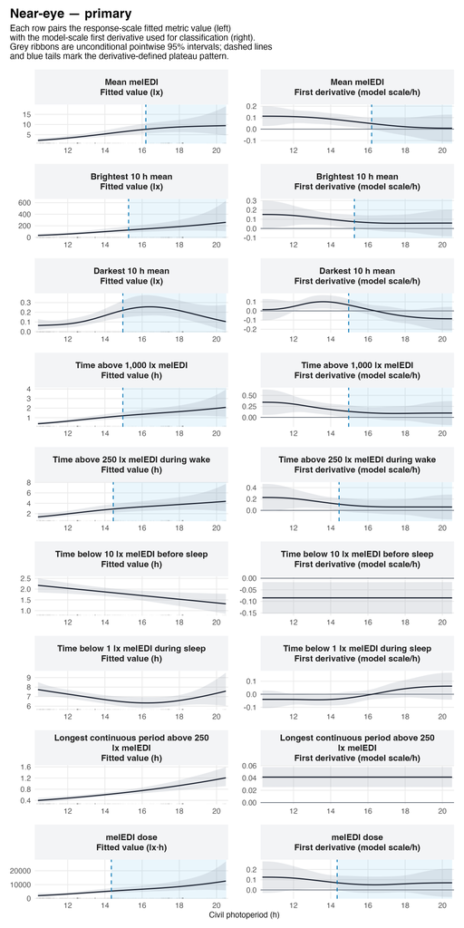

Paired primary near-eye fitted curves and first derivatives from the adapted site- and participant-adjusted GAMs. Each row shows the fitted metric value on the response scale at left and the first derivative of the photoperiod smooth on the model/link scale at right. Grey ribbons are unconditional pointwise 95% intervals. A dashed blue line marks the positive-to-zero-compatible transition, and blue shading continues through the maximum recorded photoperiod when every later derivative interval contains zero. Rugs show metric-specific participant-day photoperiods. The classification is post-result and descriptive, with no curve-wide or cross-metric multiplicity control.

## Complementary chest results

Complementary chest derivative-defined plateau patterns

Same pointwise rule as the primary analysis; chest does not override near-eye findings

| Metric | Pattern | Transition bracket | Zero-compatible tail | Reason when absent |
| --- | --- | --- | --- | --- |
| Mean melEDI | Yes | 15.58–15.68 h | 15.68–20.52 h (4.84 h) | — |
| Brightest 10 h mean | No | — | — | Detected increase persists at recorded end |
| Darkest 10 h mean | Yes | 14.14–14.24 h | 14.24–20.52 h (6.28 h) | — |
| Time above 1,000 lx melEDI | Yes | 13.42–13.52 h | 13.52–20.52 h (7.00 h) | — |
| Time above 250 lx melEDI during wake | Yes | 13.01–13.11 h | 13.11–20.52 h (7.41 h) | — |
| Time below 10 lx melEDI before sleep | No | — | — | No earlier pointwise detected increase |
| Time below 1 lx melEDI during sleep | Yes | 18.36–18.47 h | 18.47–20.52 h (2.06 h) | — |
| Longest continuous period above 250 lx melEDI | Yes | 13.73–13.83 h | 13.83–20.52 h (6.69 h) | — |
| melEDI dose | Yes | 13.11–13.21 h | 13.21–20.52 h (7.31 h) | — |

The complementary display uses the same row-wise paired structure and the same distinct response and derivative axes as the primary display.

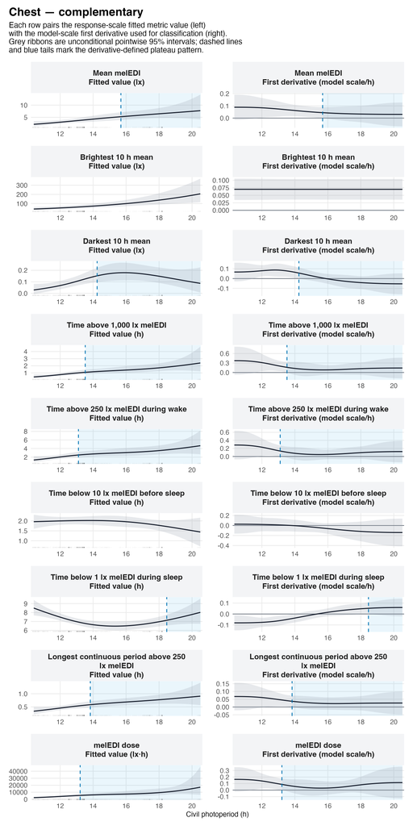

Paired complementary chest fitted curves and first derivatives from the adapted site- and participant-adjusted GAMs. Each row places the response-scale fitted value at left and the model-scale first derivative at right; uncertainty, transition markings, rugs, and post-result interpretation match the primary display. Chest lacks Tübingen and is complementary rather than a placement-equivalence analysis.

Source CSV for the fitted smooths

Source CSV for the derivatives

Paired-figure settings

Exact revised settings

## Sensitivity to the V0 derivative settings

The revised primary calculation improves the finite-difference and covariance handling but retains the requested pointwise logic. Repeating the rule with V0’s forward difference, `eps = 1e-7`, and conditional covariance gives the same yes/no classification for all 18 metric-placement combinations. Boundary locations are not equally stable: among classified patterns, the revised start is 0.21–1.96 h earlier than under the V0 settings.

Derivative-method sensitivity of the plateau boundary

The binary classification agrees for all 18 combinations; boundary timing remains method-dependent

| Metric | Revised start | V0-setting start | Revised minus V0 |
| --- | --- | --- | --- |
| Near-eye — primary |  |  |  |
| Mean melEDI | 16.20 h | 16.41 h | -0.21 h |
| Brightest 10 h mean | 15.27 h | 16.41 h | -1.13 h |
| Darkest 10 h mean | 14.96 h | 15.27 h | -0.31 h |
| Time above 1,000 lx melEDI | 14.96 h | 15.89 h | -0.93 h |
| Time above 250 lx melEDI during wake | 14.45 h | 15.07 h | -0.62 h |
| melEDI dose | 14.35 h | 16.30 h | -1.96 h |
| Chest — complementary |  |  |  |
| Mean melEDI | 15.68 h | 16.51 h | -0.82 h |
| Darkest 10 h mean | 14.24 h | 14.55 h | -0.31 h |
| Time above 1,000 lx melEDI | 13.52 h | 14.04 h | -0.51 h |
| Time above 250 lx melEDI during wake | 13.11 h | 13.42 h | -0.31 h |
| Time below 1 lx melEDI during sleep | 18.47 h | 18.88 h | -0.41 h |
| Longest continuous period above 250 lx melEDI | 13.83 h | 15.07 h | -1.24 h |
| melEDI dose | 13.21 h | 13.73 h | -0.51 h |

**WarningWhat this revised result does and does not show**

The visible derivative pattern answers the owner’s simplified question. It does not resolve the near-perfect concurvity of the photoperiod component, the site–latitude identity, collection-period composition, sparse upper-tail site representation, pointwise grid search, or site influence. A pointwise interval containing zero means that a non-zero derivative was not detected at that grid point; it does not show that the remaining slope is zero or negligible.

# Association, shape, and diagnostic support

## Multiplicity and p-value disposition

Each placement contains four complete nine-metric families: registered association, registered nonlinear shape, adapted association, and adapted nonlinear shape. All eight family registries contain exactly nine rows. No scientific p-value is displayed because the registered tests fail structural latitude–site identifiability and the adapted tests fail the concurvity gate. Consequently, REPORT-008 has no releasable p-value to format or bold.

Nine-metric multiplicity families

Rows remain in their planned family even when the p-value is withheld

| Placement | Scope | Test | Observed / planned | Status |
| --- | --- | --- | --- | --- |
| Near-eye — primary | Adapted photoperiod | Association | 9 / 9 | PASS |
| Near-eye — primary | Adapted photoperiod | Nonlinear shape | 9 / 9 | PASS |
| Near-eye — primary | Registered tensor | Association | 9 / 9 | PASS |
| Near-eye — primary | Registered tensor | Nonlinear shape | 9 / 9 | PASS |
| Chest — complementary | Adapted photoperiod | Association | 9 / 9 | PASS |
| Chest — complementary | Adapted photoperiod | Nonlinear shape | 9 / 9 | PASS |
| Chest — complementary | Registered tensor | Association | 9 / 9 | PASS |
| Chest — complementary | Registered tensor | Nonlinear shape | 9 / 9 | PASS |

## Conditional AIC evidence

The table reports `AIC(full) - AIC(reduced)`. Negative values favour the full model conditionally; positive values favour the reduced model. For association the full model is the adapted smooth and the reduced model is the null. For shape the full model is the adapted smooth and the reduced model is the linear photoperiod model. These mixed AIC patterns are not significance tests and do not establish a ceiling.

Adapted photoperiod conditional AIC comparisons

Secondary relative-support evidence only; no p-value or ceiling decision

| Metric | Association ΔAIC | Association reading | Shape ΔAIC | Shape reading | P-value status |
| --- | --- | --- | --- | --- | --- |
| Near-eye — primary |  |  |  |  |  |
| Mean melEDI | -3.23 | Full lower by >2 | 0.32 | Reduced lower | Withheld — concurvity |
| Brightest 10 h mean | -1.49 | Full lower by 0–2 | 0.73 | Reduced lower | Withheld — concurvity |
| Darkest 10 h mean | -6.54 | Full lower by >2 | -2.96 | Full lower by >2 | Withheld — concurvity |
| Time above 1,000 lx melEDI | -1.39 | Full lower by 0–2 | 0.01 | Reduced lower | Withheld — concurvity |
| Time above 250 lx melEDI during wake | 0.29 | Reduced lower | 1.65 | Reduced lower | Withheld — concurvity |
| Time below 10 lx melEDI before sleep | 0.05 | Reduced lower | 0.14 | Reduced lower | Withheld — concurvity |
| Time below 1 lx melEDI during sleep | 0.69 | Reduced lower | 0.88 | Reduced lower | Withheld — concurvity |
| Longest continuous period above 250 lx melEDI | -4.00 | Full lower by >2 | 0.07 | Reduced lower | Withheld — concurvity |
| melEDI dose | 1.63 | Reduced lower | 10.19 | Reduced lower | Withheld — concurvity |
| Chest — complementary |  |  |  |  |  |
| Mean melEDI | -0.86 | Full lower by 0–2 | 1.45 | Reduced lower | Withheld — concurvity |
| Brightest 10 h mean | -1.40 | Full lower by 0–2 | 0.15 | Reduced lower | Withheld — concurvity |
| Darkest 10 h mean | -4.62 | Full lower by >2 | -2.42 | Full lower by >2 | Withheld — concurvity |
| Time above 1,000 lx melEDI | 3.06 | Reduced lower | 3.36 | Reduced lower | Withheld — concurvity |
| Time above 250 lx melEDI during wake | -1.39 | Full lower by 0–2 | 0.22 | Reduced lower | Withheld — concurvity |
| Time below 10 lx melEDI before sleep | 4.66 | Reduced lower | -2.48 | Full lower by >2 | Withheld — concurvity |
| Time below 1 lx melEDI during sleep | -3.82 | Full lower by >2 | -3.05 | Full lower by >2 | Withheld — concurvity |
| Longest continuous period above 250 lx melEDI | 0.79 | Reduced lower | 3.25 | Reduced lower | Withheld — concurvity |
| melEDI dose | 1.50 | Reduced lower | 5.59 | Reduced lower | Withheld — concurvity |

## Former pooled-support rule as a design diagnostic

The support grid required at least three represented sites, 20 participants, 50 participant-days, and no site contributing more than 60% locally. Near-eye fits passed this pooled rule at only four or five isolated grid points between 10.6 and 11.0 h. The accepted continuous-run algorithm found no sustained one-hour interval. Chest fits passed the pooled rule at no grid point. No metric retained any point after all site omissions.

Under H07-002 these facts describe cross-site overlap and transportability; they no longer censor the derivative grid or veto the requested pooled-data classification. The endpoint table and grey/blue overlays are retained to make the superseded gate and its consequence auditable. Intervals are pointwise 95% confidence intervals from the adapted fit and are not simultaneous.

Former pooled-support gate: isolated near-eye grid points

Diagnostic under H07-002; four or five points do not form the former continuous run and all LOSO counts are zero

| Metric | Eligible points | Lower grid | Lower estimate (95% CI) | Upper grid | Upper estimate (95% CI) | Unit | LOSO-eligible points |
| --- | --- | --- | --- | --- | --- | --- | --- |
| Mean melEDI | 4 | 10.6 h | 2.30 (1.57 to 3.35) | 11.0 h | 2.57 (1.84 to 3.57) | lx | 0 |
| Brightest 10 h mean | 4 | 10.6 h | 35.3 (20.2 to 61.6) | 11.0 h | 40.5 (25.3 to 64.9) | lx | 0 |
| Darkest 10 h mean | 4 | 10.6 h | 0.0647 (0.0218 to 0.123) | 11.0 h | 0.0671 (0.0301 to 0.115) | lx | 0 |
| Time above 1,000 lx melEDI | 4 | 10.6 h | 0.403 (0.264 to 0.616) | 11.0 h | 0.463 (0.327 to 0.655) | h | 0 |
| Time above 250 lx melEDI during wake | 5 | 10.6 h | 1.44 (0.974 to 2.14) | 11.0 h | 1.58 (1.13 to 2.21) | h | 0 |
| Time below 10 lx melEDI before sleep | 5 | 10.6 h | 2.16 (1.84 to 2.48) | 11.0 h | 2.12 (1.83 to 2.42) | h | 0 |
| Time below 1 lx melEDI during sleep | 5 | 10.6 h | 7.68 (7.04 to 8.38) | 11.0 h | 7.56 (7.03 to 8.13) | h | 0 |
| Longest continuous period above 250 lx melEDI | 4 | 10.6 h | 0.408 (0.333 to 0.497) | 11.0 h | 0.428 (0.355 to 0.513) | h | 0 |
| melEDI dose | 4 | 10.6 h | 2179. (1232. to 3852.) | 11.0 h | 2444. (1540. to 3880.) | lx·h | 0 |

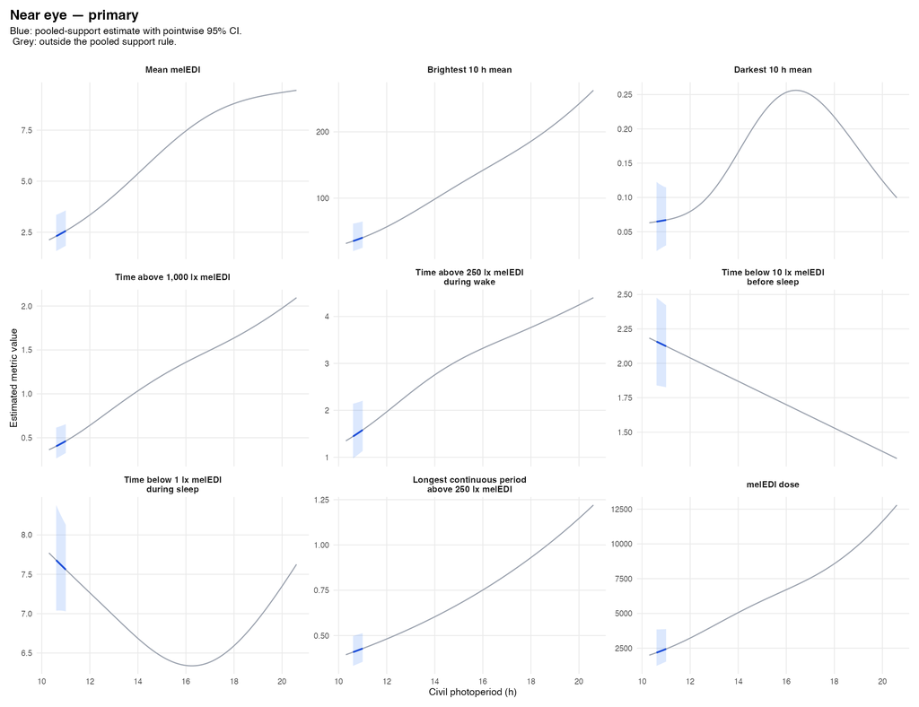

Diagnostic overlay of the superseded H07-001 pooled-support rule on primary near-eye adapted photoperiod curves. Blue segments and ribbons mark isolated points passing that former rule; grey segments do not. H07-002 evaluates the derivative over the full recorded range, so this overlay limits cross-site interpretation rather than eligibility.

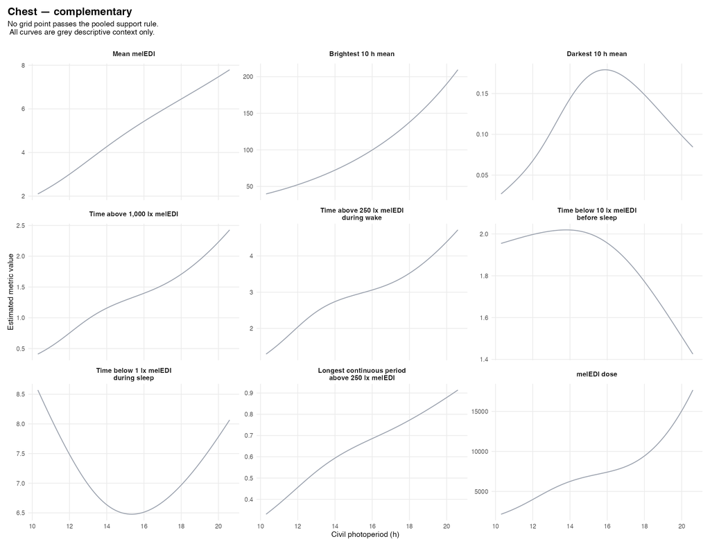

Diagnostic overlay of the superseded H07-001 pooled-support rule on complementary chest adapted photoperiod curves. No grid point passes that former rule, so every curve is grey. H07-002 nevertheless evaluates the requested pooled-data derivative pattern over the full recorded range while retaining this limitation.

Source CSV for both curve figures

# Diagnostics

## Latitude, site, participant, and collection period

Each site has one absolute latitude. The primary near-eye data therefore have nine site latitudes and the chest data eight; latitude is not replicated independently within site. Collection periods differ by site, and several sites cover narrow or disjoint photoperiod regions. Site, latitude, photoperiod, and collection period cannot be interpreted as separable effects.

The site table shows the range across metric-specific samples. Its ordering and names follow the submitted manuscript display registry.

Metric-specific site support and collection periods

Ranges reflect metric-specific complete rows; absolute latitude is constant within site

| Site | Participants | Participant-days | Collection period | Absolute latitude | Photoperiod range |
| --- | --- | --- | --- | --- | --- |
| Near-eye — primary |  |  |  |  |  |
| Borås (SE) | 13 | 67–78 | 2025-03-04 to 2025-10-12 | 57.7° | 11.90–20.52 h |
| Delft (NL) | 12–13 | 50–78 | 2025-02-22 to 2025-09-27 | 52.0° | 11.59–18.22 h |
| Dortmund (DE) | 18 | 84–107 | 2025-06-11 to 2025-10-19 | 51.5° | 11.58–18.22 h |
| Tübingen (DE) | 26 | 132–150 | 2023-08-15 to 2023-11-12 | 48.5° | 10.50–15.53 h |
| Munich (DE) | 10 | 52–60 | 2024-05-14 to 2024-07-28 | 48.1° | 16.41–17.45 h |
| Madrid (ES) | 23 | 105–129 | 2024-10-08 to 2025-02-09 | 40.4° | 10.33–12.35 h |
| Izmir (TR) | 17 | 82–101 | 2024-12-24 to 2025-06-01 | 38.3° | 10.49–15.70 h |
| San José (CR) | 6 | 25–32 | 2025-06-17 to 2025-06-29 | 9.9° | 13.47–13.47 h |
| Kumasi (GH) | 14–15 | 58–81 | 2024-10-08 to 2025-02-02 | 6.7° | 12.49–12.71 h |
| Chest — complementary |  |  |  |  |  |
| Borås (SE) | 16 | 81–96 | 2025-03-04 to 2025-10-19 | 57.7° | 11.35–20.52 h |
| Delft (NL) | 14–15 | 63–93 | 2025-02-22 to 2025-10-13 | 52.0° | 11.59–18.22 h |
| Dortmund (DE) | 20 | 92–114 | 2025-06-11 to 2025-10-19 | 51.5° | 11.58–18.21 h |
| Munich (DE) | 10 | 52–60 | 2024-05-14 to 2024-07-28 | 48.1° | 16.41–17.45 h |
| Madrid (ES) | 22 | 103–123 | 2024-10-08 to 2025-02-09 | 40.4° | 10.33–12.35 h |
| Izmir (TR) | 17 | 83–102 | 2024-12-24 to 2025-06-01 | 38.3° | 10.49–15.70 h |
| San José (CR) | 39 | 208–230 | 2025-06-17 to 2025-09-06 | 9.9° | 12.96–13.47 h |
| Kumasi (GH) | 15 | 61–84 | 2024-10-08 to 2025-02-01 | 6.7° | 12.49–12.71 h |

The decisive support limitation is visible in the table: Kumasi and San José cover narrow photoperiod bands, Munich covers only a short high-photoperiod period, Tübingen appears only near eye, and the northern sites cover broad but different collection windows. Repeated participant-days increase precision within these cells but do not create independent latitude or site replication.

## Concurvity, basis, and numerical diagnostics

For all 18 adapted smooth fits, the estimated worst concurvity for the target photoperiod smooth is 0.9987–0.9989. Pairwise decomposition identifies the participant random-effect smooth as the dominant supplier (0.9985–0.9988); the site random-effect smooth contributes approximately 0.483–0.550. This is not a minor warning: the participant structure can nearly reproduce the photoperiod smooth, so approximate whole-term tests are withheld.

Adapted smooth diagnostics

Diagnostic p-values are used only to flag basis checks; scientific p-values remain withheld

| Metric | Smooth edf | k-index | Basis check | Estimated concurvity | Pooled day-lag 1 | Temporal gate | Inference |
| --- | --- | --- | --- | --- | --- | --- | --- |
| Near-eye — primary |  |  |  |  |  |  |  |
| Mean melEDI | 2.21 | 0.921 | Flagged | 0.9987 | +0.015 | Pass | Withheld |
| Brightest 10 h mean | 1.97 | 0.964 | Not flagged | 0.9987 | +0.017 | Pass | Withheld |
| Darkest 10 h mean | 3.24 | 1.000 | Not flagged | 0.9987 | -0.095 | Pass | Withheld |
| Time above 1,000 lx melEDI | 2.35 | 0.823 | Flagged | 0.9987 | -0.112 | Pass | Withheld |
| Time above 250 lx melEDI during wake | 2.13 | 0.891 | Flagged | 0.9988 | +0.068 | Pass | Withheld |
| Time below 10 lx melEDI before sleep | 1.00 | 1.028 | Not flagged | 0.9989 | -0.229 | Pass | Withheld |
| Time below 1 lx melEDI during sleep | 2.67 | 0.956 | Not flagged | 0.9988 | +0.006 | Pass | Withheld |
| Longest continuous period above 250 lx melEDI | 1.00 | 0.986 | Not flagged | 0.9987 | -0.001 | Pass | Withheld |
| melEDI dose | 2.00 | 0.982 | Not flagged | 0.9987 | -0.008 | Pass | Withheld |
| Chest — complementary |  |  |  |  |  |  |  |
| Mean melEDI | 1.81 | 0.922 | Flagged | 0.9987 | -0.032 | Pass | Withheld |
| Brightest 10 h mean | 1.00 | 0.954 | Not flagged | 0.9987 | -0.036 | Pass | Withheld |
| Darkest 10 h mean | 2.77 | 1.002 | Not flagged | 0.9987 | -0.009 | Pass | Withheld |
| Time above 1,000 lx melEDI | 2.61 | 0.893 | Not flagged | 0.9987 | -0.051 | Pass | Withheld |
| Time above 250 lx melEDI during wake | 2.61 | 0.925 | Not flagged | 0.9988 | +0.045 | Pass | Withheld |
| Time below 10 lx melEDI before sleep | 1.98 | 1.032 | Not flagged | 0.9988 | -0.154 | Pass | Withheld |
| Time below 1 lx melEDI during sleep | 2.94 | 0.956 | Not flagged | 0.9987 | +0.014 | Pass | Withheld |
| Longest continuous period above 250 lx melEDI | 2.03 | 1.009 | Not flagged | 0.9987 | -0.017 | Pass | Withheld |
| melEDI dose | 2.61 | 0.966 | Not flagged | 0.9987 | -0.030 | Pass | Withheld |

## Temporal dependence

All 162 main fits pass the prespecified descriptive dependence gate. The largest absolute pooled consecutive-day lag-1 correlation is 0.232, below the 0.30 trigger. No AR(1) or participant-cluster correction is added. Passing this gate does not repair the cross-site or concurvity failures.

## Residual distributions and physical bounds

Residual checks show response-specific limitations rather than one uniform failure. Across placements, the Pearson-residual normal-quantile correlation ranges from approximately 0.952 to 0.998, residual excess kurtosis reaches 8.35, and the maximum absolute fitted-versus-absolute-residual correlation is 0.348. The strongest tail or shape departures occur for darkest 10 h mean, melEDI dose, mean melEDI, brightest 10 h mean, and the sleep-environment duration. These patterns make Gaussian-response intervals provisional where applicable; they do not justify a result-selected family switch.

No observed metric value is negative and no observed duration exceeds 24 h. After correcting the H07-local fitted-range diagnostic so that `fitted.gam()` Tweedie response-scale values are not exponentiated twice, all adapted-fit duration fitted values span 0.15–9.62 h. A pointwise lower curve bound for complementary chest darkest 10 h mean crosses zero outside any supported region; the point estimate does not. This reinforces the decision not to interpret chest curves outside support.

Residual-distribution summary

Pearson residuals from the adapted smooth fits

| QQ correlation range | Skewness range | Maximum excess kurtosis | Maximum \|cor(fitted, \|residual\|)\| | Maximum proportion \|Pearson\| > 3 | Observed negative values | Placement |
| --- | --- | --- | --- | --- | --- | --- |
| 0.952–0.998 | -1.58 to +0.96 | 7.94 | 0.348 | 0.003 | 0 | Near-eye — primary |
| 0.960–0.996 | -1.42 to +1.47 | 8.35 | 0.335 | 0.006 | 0 | Chest — complementary |

## Tweedie 100-simulation pilot

No post-hoc alternative model has been fitted. The recommended Stage 2 disposition is to retain this metric as descriptive and non-inferential rather than reopen the common-family contract when all H07 association tests are already withheld for design reasons.

Tweedie distribution pilot

100 simulations only; pilot is diagnostic, not inferential or manuscript-ready

[output not shown]

# Sensitivity and influence analyses

## Exact sensitivity samples

The paired placement branch uses only participant-days with both placements: 110–112 participants, 505–643 participant-days, and eight sites, depending on metric. The gap-timing-unaware branch contains 140–141 near-eye participants and 755–811 participant-days, and 153–154 chest participants and 839–897 participant-days. Exact preparation-common rows are evaluated separately from the total dataset difference.

The exactly identified longest-period sensitivity contains 132 participants and 500 participant-days near eye and 150 participants and 564 participant- days at the chest. The observed and corrected dose comparison uses the same 141 participants and 761 participant-days near eye and 154 participants and 851 participant-days at the chest.

Sensitivity sample ranges across metric-specific rows

A single value is shown when every included metric uses the same sample

| Sensitivity | Placement | Participants | Participant-days | Observations | Sites | Collection period |
| --- | --- | --- | --- | --- | --- | --- |
| Exactly identified longest period | Near-eye — primary | 132 | 500 | 500 | 9 | 2023-08-15 to 2025-10-19 |
| Exactly identified longest period | Chest — complementary | 150 | 564 | 564 | 8 | 2024-05-16 to 2025-10-19 |
| Gap-timing-unaware dataset | Near-eye — primary | 140–141 | 755–811 | 755–811 | 9 | 2023-08-15 to 2025-10-19 |
| Gap-timing-unaware dataset | Chest — complementary | 153–154 | 839–897 | 839–897 | 8 | 2024-05-14 to 2025-10-19 |
| Observed/corrected dose common rows | Near-eye — primary | 141 | 761 | 761 | 9 | 2023-08-15 to 2025-10-19 |
| Observed/corrected dose common rows | Chest — complementary | 154 | 851 | 851 | 8 | 2024-05-14 to 2025-10-19 |
| Paired/common placement | Near-eye — primary | 110–112 | 505–643 | 505–643 | 8 | 2024-05-14 to 2025-10-19 |
| Paired/common placement | Chest — complementary | 110–112 | 505–643 | 505–643 | 8 | 2024-05-14 to 2025-10-19 |
| Preparation exact-common rows | Near-eye — primary | 139–141 | 653–809 | 653–809 | 9 | 2023-08-15 to 2025-10-19 |
| Preparation exact-common rows | Chest — complementary | 153–154 | 740–894 | 740–894 | 8 | 2024-05-14 to 2025-10-19 |

## Revised derivative-pattern sensitivity

The simplified classification is not uniformly stable across the already approved data branches. The gap-timing-unaware dataset reproduces all nine near-eye classifications and eight of nine chest classifications; chest melEDI dose loses its main-data pattern. The exact preparation-common branches reproduce all near-eye classifications, while time below 1 lx melEDI during sleep loses its chest classification in both common-row scenarios. Corrected and observed dose agree on their common sample at both placements.

The paired/common placement sample is the most consequential change. Only four of nine near-eye classifications agree with the main all-available analysis: the patterns for brightest and darkest 10 h means, both bright-light duration metrics, and melEDI dose are no longer detected. Six of nine chest classifications agree; the sleep-environment duration, longest-period, and dose patterns disappear. In the exactly identified longest-period sensitivity, near eye changes from no pattern to a transition at 15.38–15.48 h.

Sensitivity of the revised derivative classification

Agreement compares each branch with its placement-specific main all-available result; changed classifications remain reportable limitations, not exclusion gates

| Sensitivity | Placement | Run | Agreement | Changed metrics | Boundary-shift range |
| --- | --- | --- | --- | --- | --- |
| Exactly identified longest period | Near-eye — primary | exact_period__near_eye | 0/1 | Longest continuous period above 250 lx melEDI | Not applicable |
| Exactly identified longest period | Chest — complementary | exact_period__chest | 1/1 | None | +0.00 to +0.00 h |
| Gap-timing-unaware dataset | Near-eye — primary | gap_timing_unaware__near_eye | 9/9 | None | -0.21 to +1.75 h |
| Gap-timing-unaware dataset | Chest — complementary | gap_timing_unaware__chest | 8/9 | melEDI dose | -0.10 to +0.72 h |
| Observed/corrected dose common rows | Near-eye — primary | dose_common_corrected__near_eye | 1/1 | None | +0.00 to +0.00 h |
| Observed/corrected dose common rows | Near-eye — primary | dose_common_observed__near_eye | 1/1 | None | +0.10 to +0.10 h |
| Observed/corrected dose common rows | Chest — complementary | dose_common_corrected__chest | 1/1 | None | +0.00 to +0.00 h |
| Observed/corrected dose common rows | Chest — complementary | dose_common_observed__chest | 1/1 | None | +0.00 to +0.00 h |
| Paired/common placement | Near-eye — primary | paired__near_eye | 4/9 | Brightest 10 h mean; Darkest 10 h mean; Time above 1,000 lx melEDI; Time above 250 lx melEDI during wake; melEDI dose | +0.21 to +0.21 h |
| Paired/common placement | Chest — complementary | paired__chest | 6/9 | Time below 1 lx melEDI during sleep; Longest continuous period above 250 lx melEDI; melEDI dose | +0.10 to +3.60 h |
| Preparation exact-common rows | Near-eye — primary | prep_common_gap__near_eye | 9/9 | None | -0.21 to +0.10 h |
| Preparation exact-common rows | Near-eye — primary | prep_common_primary__near_eye | 9/9 | None | -0.21 to +0.00 h |
| Preparation exact-common rows | Chest — complementary | prep_common_gap__chest | 8/9 | Time below 1 lx melEDI during sleep | -0.10 to +0.10 h |
| Preparation exact-common rows | Chest — complementary | prep_common_primary__chest | 8/9 | Time below 1 lx melEDI during sleep | -0.10 to +0.10 h |

Source CSV for the revised sensitivity comparison

## Former support-restricted curve comparisons

These H07-001 curve comparisons are retained as diagnostics. All 58 remain inferentially non-estimable because every relevant adapted smooth has the concurvity warning. Paired placement and exactly identified longest-period comparisons have no common pooled support. All chest preparation and dose comparisons also have no common pooled support.

For near eye, the two preparation comparisons retain the same direction over only four or five isolated points for all nine metrics. Corrected and observed melEDI dose also retain the same direction over four points, with maximum absolute log ratio 0.031. No scientific magnitude threshold was fixed, so these are descriptive direction checks, not stability or equivalence claims. H07-002’s full-range pointwise derivative classification is summarized separately above.

Sensitivity comparison disposition

Direction is summarized only where both curves have pooled-eligible points

| Comparison | Placement | Comparisons | With common pooled points | Same direction where comparable | No common pooled support | Inferentially non-estimable |
| --- | --- | --- | --- | --- | --- | --- |
| Exactly identified longest period | Near-eye — primary | 1 | 0 | 0 | 1 | 1 |
| Exactly identified longest period | Chest — complementary | 1 | 0 | 0 | 1 | 1 |
| Observed vs corrected dose | Near-eye — primary | 1 | 1 | 1 | 0 | 1 |
| Observed vs corrected dose | Chest — complementary | 1 | 0 | 0 | 1 | 1 |
| Paired/common placement sample | Near-eye — primary | 9 | 0 | 0 | 9 | 9 |
| Paired/common placement sample | Chest — complementary | 9 | 0 | 0 | 9 | 9 |
| Primary vs gap-timing-unaware — exact-common values | Near-eye — primary | 9 | 9 | 9 | 0 | 9 |
| Primary vs gap-timing-unaware — exact-common values | Chest — complementary | 9 | 0 | 0 | 9 | 9 |
| Primary vs gap-timing-unaware — total difference | Near-eye — primary | 9 | 9 | 9 | 0 | 9 |
| Primary vs gap-timing-unaware — total difference | Chest — complementary | 9 | 0 | 0 | 9 | 9 |

## Basis and site representation

Applying H07-002’s full-range derivative rule shows two classification changes. The expanded-basis chest model no longer classifies time below 1 lx melEDI during sleep; its near-eye longest-period fit remains unavailable after the Hessian failure. The fixed-site representation also removes that chest sleep-environment classification and adds a near-eye longest-period pattern at 14.86–14.96 h. Thus 16 of 17 evaluable expanded-basis classifications and 16 of 18 fixed-site classifications agree with the main model.

Model-form sensitivity summary

All alternative smooths retain the concurvity warning

| Placement | Alternative model | Fits | Failed fits | Comparable curves | Same direction | Largest absolute log ratio |
| --- | --- | --- | --- | --- | --- | --- |
| Near-eye — primary | Expanded photoperiod basis | 9 | 1 | 9 | 9 | 0.014 |
| Near-eye — primary | Fixed-site equal-site average | 9 | 0 | 9 | 9 | 0.353 |
| Chest — complementary | Expanded photoperiod basis | 9 | 0 | 0 | 0 | Not estimable |
| Chest — complementary | Fixed-site equal-site average | 9 | 0 | 0 | 0 | Not estimable |

Model-form sensitivity of the revised derivative classification

Every evaluable alternative retains the concurvity warning; agreement is descriptive

| Placement | Alternative model | Evaluable | Agreement | Changed or unavailable metrics | Boundary-shift range |
| --- | --- | --- | --- | --- | --- |
| Near-eye — primary | Expanded photoperiod basis | 8 | 8/8 | Longest continuous period above 250 lx melEDI | -0.41 to -0.21 h |
| Near-eye — primary | Fixed-site representation | 9 | 8/9 | Longest continuous period above 250 lx melEDI | -1.13 to +0.41 h |
| Chest — complementary | Expanded photoperiod basis | 9 | 8/9 | Time below 1 lx melEDI during sleep | -0.41 to -0.10 h |
| Chest — complementary | Fixed-site representation | 9 | 8/9 | Time below 1 lx melEDI during sleep | -0.10 to +3.09 h |

Source CSV for the revised model-form comparison

## Leave-one-site-out influence

All 153 leave-one-site-out fits converge, and all retain the concurvity warning. No metric has full support under the superseded leave-one-site-out eligibility rule. H07-002 instead treats each omission as an influence check over that omitted dataset’s complete recorded photoperiod range.

Near-eye mean melEDI and both low-light duration classifications agree after all nine omissions. For five primary near-eye plateau patterns, eight of nine omissions retain the classification; omitting Munich is the discordant case. The main near-eye longest-period result is especially site-sensitive: four of nine omissions create a pattern that is absent in the full fit. At the chest, mean melEDI, time above 1,000 lx melEDI, and time below 10 lx melEDI before sleep agree after all eight omissions. Other chest classifications are more site-sensitive; the sleep-environment pattern remains after only three of eight omissions.

These findings do not veto the requested pooled-data classification, but they show that several patterns and their transition hours depend on which sites define the photoperiod curve. They do not identify a causal site effect.

Leave-one-site-out influence on the revised derivative pattern

Influence diagnostic only; classification disagreement does not operate as an H07-002 exclusion rule

| Metric | Main pattern | Patterns after omission | Agreement with main | Discordant omissions | Transition range after omission |
| --- | --- | --- | --- | --- | --- |
| Near-eye — primary |  |  |  |  |  |
| Mean melEDI | Yes | 9/9 | 9/9 | None | 15.38–16.41 h |
| Brightest 10 h mean | Yes | 8/9 | 8/9 | MPI | 13.83–16.41 h |
| Darkest 10 h mean | Yes | 8/9 | 8/9 | MPI | 14.24–15.07 h |
| Time above 1,000 lx melEDI | Yes | 8/9 | 8/9 | MPI | 13.44–16.51 h |
| Time above 250 lx melEDI during wake | Yes | 8/9 | 8/9 | MPI | 13.68–14.86 h |
| Time below 10 lx melEDI before sleep | No | 0/9 | 9/9 | None | None |
| Time below 1 lx melEDI during sleep | No | 0/9 | 9/9 | None | None |
| Longest continuous period above 250 lx melEDI | No | 4/9 | 5/9 | BAUA; FUSPCEU; UCR; KNUST | 15.05–16.20 h |
| melEDI dose | Yes | 8/9 | 8/9 | MPI | 13.76–15.99 h |
| Chest — complementary |  |  |  |  |  |
| Mean melEDI | Yes | 8/8 | 8/8 | None | 13.76–16.10 h |
| Brightest 10 h mean | No | 2/8 | 6/8 | IZTECH; KNUST | 12.70–15.07 h |
| Darkest 10 h mean | Yes | 7/8 | 7/8 | IZTECH | 13.36–14.45 h |
| Time above 1,000 lx melEDI | Yes | 8/8 | 8/8 | None | 12.48–14.45 h |
| Time above 250 lx melEDI during wake | Yes | 6/8 | 6/8 | THUAS; IZTECH | 12.16–13.52 h |
| Time below 10 lx melEDI before sleep | No | 0/8 | 8/8 | None | None |
| Time below 1 lx melEDI during sleep | Yes | 3/8 | 3/8 | RISE; TUM; FUSPCEU; IZTECH; UCR | 18.47–18.67 h |
| Longest continuous period above 250 lx melEDI | Yes | 7/8 | 7/8 | RISE | 13.13–15.48 h |
| melEDI dose | Yes | 7/8 | 7/8 | IZTECH | 12.80–14.35 h |

Source CSV for the revised leave-one-site-out comparison

Former support-restricted leave-one-site-out magnitude summary

Retained for H07-001 provenance; the revised full-range classification is reported above

[output not shown]

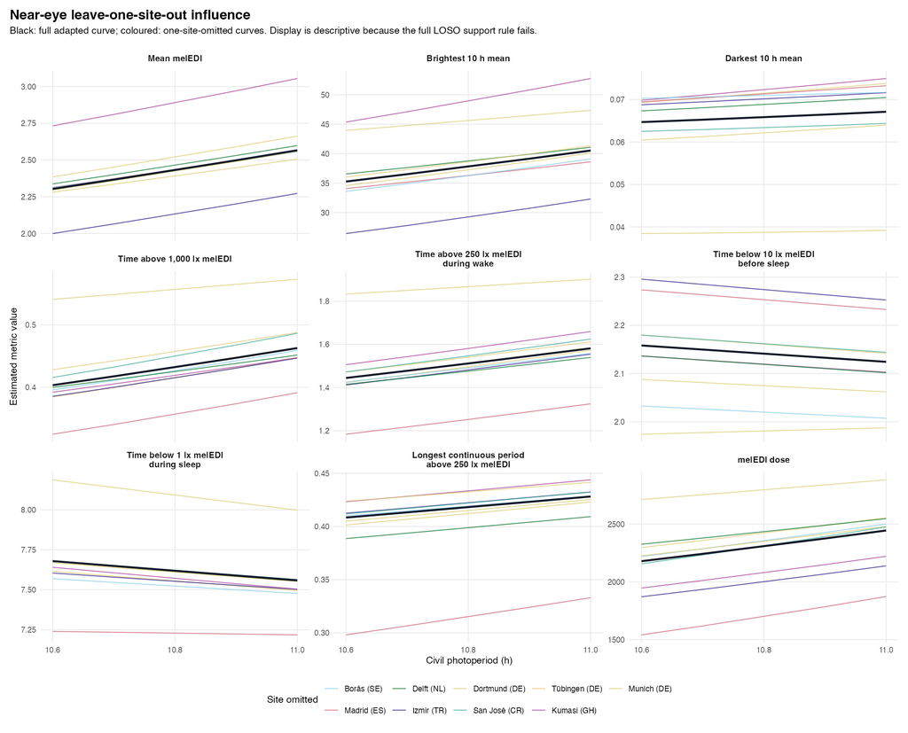

Diagnostic H07-001 leave-one-site-out curves over the former isolated pooled-supported grid. The black curve is the full adapted fit and colours use the submitted site palette. H07-002 uses the full-range classification table above; this narrower display remains useful for visualizing local site influence.

Source CSV for the leave-one-site-out figure

# H11 implementation comparison

H11’s difficulty does not imply that H07 should use `discrete = FALSE`. H11 originally planned ML/non-discrete comparisons for large half-hourly Gaussian models with an AR(1) boundary structure. That branch produced no accepted checkpoint and was replaced by inference from an existing fREML/discrete fit using AR-whitened participant-cluster CR1 covariance. H11’s method targets a complete 24-hour sex-difference curve under serial correlation.

H07 instead has one participant-day row per outcome, exact `gam(REML)` fits completed quickly, and the temporal trigger was not crossed. Its remaining limitations are that latitude is determined by site, photoperiod is nearly reproduced by participant structure, and cross-site joint support is sparse. Neither `bam(discrete = FALSE)` nor H11’s CR1 covariance changes those design facts. The computational choice is therefore retained: exact `gam(REML)`, no `bam()` fallback, no ML branch, and no transferred CR1 procedure. H07-002 changes the descriptive derivative estimand, not the fitting engine.

# Reproduction of the V0 GAM-derivative method

## Exact V0 specification

V0 first selected outcome-placement pairs using `AIC(full) - AIC(null) < -2`. It fitted Gaussian `log10(value + 0.1)` models with `mgcv::bam()`, fREML, `discrete = TRUE`, and ten threads. It then used a 100-point forward derivative with `eps = 1e-7`, a conditional covariance matrix, and pointwise 95% confidence limits. The last grid point with a positive lower limit became the reported boundary.

```r
for (index in seq_len(nrow(v0_formulas))) {
  cat(
    v0_formulas$formula_id[[index]],
    ": ",
    v0_formulas$formula[[index]],
    " | engine = ",
    v0_formulas$engine[[index]],
    ", method = ",
    v0_formulas$method[[index]],
    ", discrete = ",
    v0_formulas$discrete[[index]],
    ", nthreads = ",
    v0_formulas$nthreads[[index]],
    "\n",
    sep = ""
  )
}
```

```
H7_full: log_zero_inflated(metric) ~ s(photoperiod) + s(site, bs = "re") +      s(Id, bs = "re") | engine = mgcv::bam, method = fREML, discrete = TRUE, nthreads = 10
H7_null: log_zero_inflated(metric) ~ s(site, bs = "re") + s(Id, bs = "re") | engine = mgcv::bam, method = fREML, discrete = TRUE, nthreads = 10
```

## Numeric reconstruction

The reconstructed boundary reaches the maximum observed photoperiod (20.52 h) for near-eye longest continuous period and melEDI dose, and for chest brightest 10 h mean and melEDI dose. These edge cases fail H07-002 because there is no subsequent zero-compatible pointwise tail.

Applying H07-002’s added through-the-recorded-end requirement to the complete V0 derivative curves classifies eight of the 14 V0 candidate combinations and six of the ten historically AIC-retained combinations. This confirms that the revised rule is not merely a relabelling of V0’s last-positive point.

H07-002 rule applied to the reconstructed V0 derivative curves

Historical comparison only; V0 did not analyse all nine metrics independently

| Metric | V0 AIC retained | H07-002 pattern | Transition or reason |
| --- | --- | --- | --- |
| Near-eye — primary |  |  |  |
| Mean melEDI | Yes | Yes | 16.10–16.20 h |
| Brightest 10 h mean | Yes | Yes | 16.41–16.51 h |
| Darkest 10 h mean | Yes | Yes | 14.65–14.76 h |
| Time above 1,000 lx melEDI | Yes | Yes | 16.61–16.71 h |
| Time above 250 lx melEDI during wake | No | Yes | 17.74–17.85 h |
| Time below 10 lx melEDI before sleep | No | No | No prior detected increase |
| Longest continuous period above 250 lx melEDI | Yes | No | Detected increase at recorded end |
| melEDI dose | Yes | No | Detected increase at recorded end |
| Chest — complementary |  |  |  |
| Mean melEDI | Yes | Yes | 16.51–16.61 h |
| Brightest 10 h mean | Yes | No | Detected increase at recorded end |
| Time above 1,000 lx melEDI | No | Yes | 18.88–18.98 h |
| Time above 250 lx melEDI during wake | No | No | Detected increase at recorded end |
| Longest continuous period above 250 lx melEDI | Yes | Yes | 16.10–16.20 h |
| melEDI dose | Yes | No | Detected increase at recorded end |

Source CSV for the revised V0 comparison

Exact V0 AIC and derivative reconstruction

The V0 boundary is the last pointwise-detected increase; H07-002 additionally requires a zero-compatible tail

| Metric | Reconstructed ΔAIC | V0 retained | Last detected increase | Derivative (95% pointwise CI) | Reproduction |
| --- | --- | --- | --- | --- | --- |
| Near-eye — primary |  |  |  |  |  |
| Mean melEDI | -5.417 | Yes | 16.10 h | 0.052 (0.001 to 0.103) | Numeric value reproduced |
| Brightest 10 h mean | -4.257 | Yes | 16.41 h | 0.064 (0.000 to 0.127) | Numeric value reproduced |
| Darkest 10 h mean | -5.167 | Yes | 14.65 h | 0.061 (0.000 to 0.121) | Numeric value reproduced |
| Time above 1,000 lx melEDI | -3.442 | Yes | 16.61 h | 0.045 (0.000 to 0.090) | Numeric value reproduced |
| Time above 250 lx melEDI during wake | -1.767 | No | 17.74 h | 0.047 (0.000 to 0.093) | Retention reproduced; rendered value absent |
| Time below 10 lx melEDI before sleep | 2.006 | No | None | Not available | Retention reproduced; rendered value absent |
| Longest continuous period above 250 lx melEDI | -3.456 | Yes | 20.52 h | 0.044 (0.028 to 0.060) | Numeric value reproduced |
| melEDI dose | -6.559 | Yes | 20.52 h | 0.074 (0.031 to 0.118) | Numeric value reproduced |
| Chest — complementary |  |  |  |  |  |
| Mean melEDI | -2.768 | Yes | 16.51 h | 0.042 (0.001 to 0.082) | Numeric value reproduced |
| Brightest 10 h mean | -2.571 | Yes | 20.52 h | 0.076 (0.043 to 0.109) | Numeric value reproduced |
| Time above 1,000 lx melEDI | -1.048 | No | 18.88 h | 0.051 (0.001 to 0.102) | Retention reproduced; rendered value absent |
| Time above 250 lx melEDI during wake | -1.455 | No | 20.52 h | 0.046 (0.004 to 0.089) | Retention reproduced; rendered value absent |
| Longest continuous period above 250 lx melEDI | -2.617 | Yes | 16.10 h | 0.028 (0.001 to 0.056) | Numeric value reproduced |
| melEDI dose | -5.481 | Yes | 20.52 h | 0.078 (0.048 to 0.109) | Numeric value reproduced |

The corrected recognizable figures restore brightest 10 h mean, remove the duplicated daily-mean panel, address metrics by stable IDs, and label dashed lines as last pointwise-detected increases. Their geometry remains the V0 geometry for comparison; the labels identify the V0 boundary rather than the revised H07-002 classification.

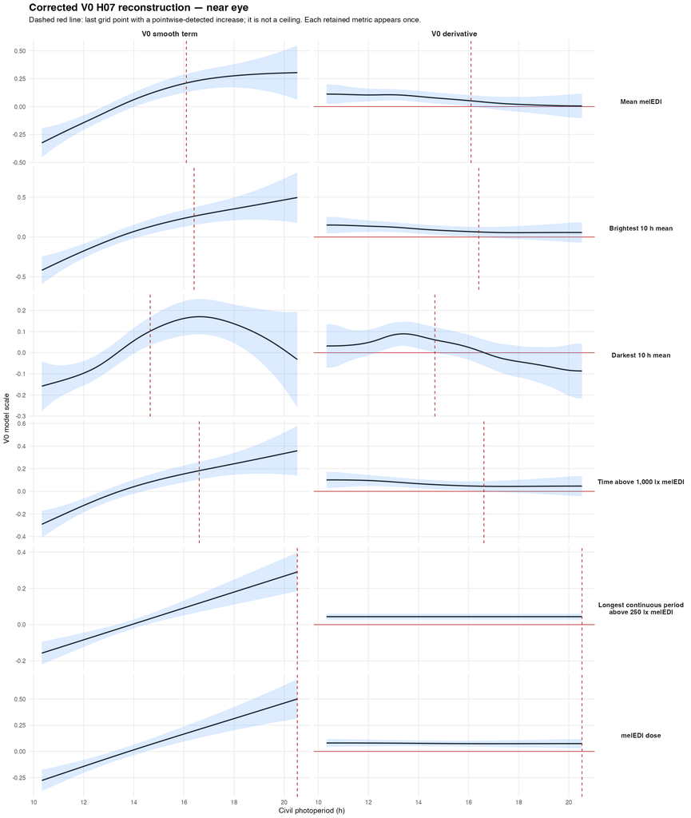

Corrected reconstruction of the V0 near-eye GAM curves and pointwise derivative rule. Dashed lines mark the last pointwise-detected increase. H07-002 additionally requires every later derivative interval to contain zero, as evaluated in the table above.

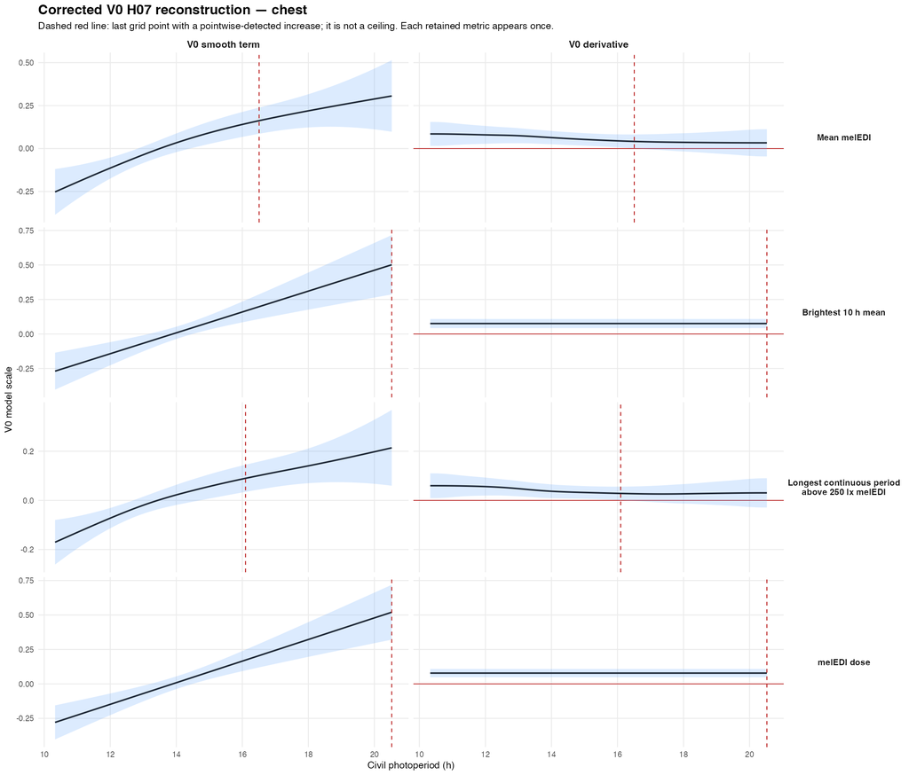

Corrected reconstruction of the V0 chest GAM curves and pointwise derivative rule. The figure is a historical comparator; H07-002’s added zero-compatible-tail classification is reported separately and is not a placement-equivalence analysis.

Source CSV for both corrected V0 figures

# Pointwise rule and optional simultaneous-band gate

H07-002’s requested classification uses the first derivative of the fitted photoperiod smooth, analytic pointwise 95% intervals, and no simulation. It therefore does not require production computation.

Before H07-002, the audit completed a 100-draw pilot for simultaneous bands of the full response prediction over only the former pooled-eligible grid. That pilot is retained below as historical implementation evidence. It is not the current derivative estimand and does not cover the full recorded range; chest has no point under that former mask.

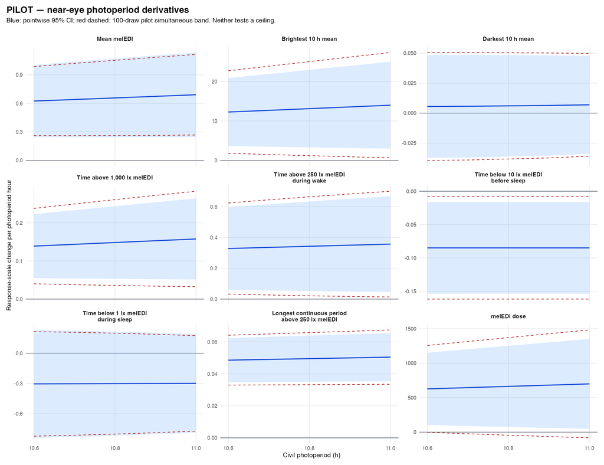

Historical H07-001 near-eye derivative validation pilot. Blue ribbons are pointwise 95% intervals and red dashed lines are 100-draw pilot simultaneous bands for full response-scale derivatives over the former isolated pooled-eligible points. H07-002 uses the full-range smooth-derivative displays above instead.

Source CSV for the derivative pilot

Historical H07-001 simultaneous-band pilot and runtime projection

No production draw has been run; a revised full-range pilot would be required before any H07-002 simultaneous sensitivity

| Metrics | Pilot draws per metric | Eligible grid points | Pilot critical-value range | Projected 10,000-draw runtime | Placement |
| --- | --- | --- | --- | --- | --- |
| 9 | 100 | 4–5 | 1.87–2.38 | 0.8–4.4 s per metric | Near-eye — primary |
| 9 | 100 | 0 | Not estimable | 0.9–9.4 s per metric | Chest — complementary |

The current recommendation remains **do not run production derivative draws** because the owner requested the simpler pointwise rule. If a stricter curve-wide sensitivity is desired, it first requires a new 100-draw pilot over the complete metric-specific range, followed by separate approval for the projected production run. Even a simultaneous zero-compatible tail would not be an equivalence test.

# Reproducibility and audit trail

Stage 2 fitted 162 main models, 234 sensitivity models, 153 leave-one-site-out models, and 28 V0 full/null models. All model frames, fit checkpoints, diagnostics, tests, support grids, curve sources, and run registries are persisted in H07-owned artifact paths. No production bootstrap or simulation was run; only the two approved 100-replicate pilots were executed. H07-002 added derivative extraction from existing checkpoints for 18 main, 78 data sensitivity, 36 model-form, 153 leave-one-site-out, and 14 V0 candidate combinations. It did not refit a model or run a simulation.

Recorded analytical environment

Every scientific calculation used R 4.6.1 and the existing project library

| Stage 2 implementation | R | mgcv | gratia | dplyr |
| --- | --- | --- | --- | --- |
| H07-STAGE2-2026-08-06-A | 4.6.1 | 1.9.4 | 0.11.2 | 1.2.1 |

Direct input manifest

Hashes were recorded before fitting

| Input | Path | SHA-256 |
| --- | --- | --- |
| Primary near-eye participant-day metrics | ./artifacts/06_model_data/base/metrics_glasses_participant_day_enriched.rds | b469fa8f0a743de1cbb1075f78879b84ab602c74cc44fb97da45dee596681f42 |
| Primary chest participant-day metrics | ./artifacts/06_model_data/base/metrics_chest_participant_day_enriched.rds | 10aebeb5dabb53e8f3ee0747b62c31707da344e11b7068261c2ada2a0b7badc9 |
| Gap-timing-unaware participant-day metrics | ./artifacts/06_model_data/scenarios/manuscript_prepared_data/participant_day_metrics.rds | 7561b5dd47cb5e23ca94ba59bd57648f11fe492f86af53a566c5c9cf42d932f1 |
| Site solar context | ./artifacts/06_model_data/context/site_solar_context.rds | 39ffe488de86f5d7cdc56d65c582c9de31f9054f8565936b4ec74e01491f26d0 |

# Revised Stage 2 author approval gate

Stage 2 stops here. Approve or revise each item before any Stage 3 report or production computation:

1. **H07-S2R-001 — inferential disposition:** accept that registered H07 is non-identifiable because absolute latitude is determined by site, and that adapted association and shape p-values are withheld because of extreme concurvity. These remain interpretation limitations rather than gates that suppress H07-002’s descriptive derivative pattern.
2. **H07-S2R-002 — revised plateau result:** accept the post-result pointwise definition and the resulting six-of-nine primary near-eye and seven-of-nine complementary chest classifications, with the exact transition brackets and absence reasons shown above. Use “derivative-defined plateau pattern” and do not translate it into equivalence, an asymptote, a mechanistic ceiling, or a causal effect.
3. **H07-S2R-003 — sensitivity and influence:** accept that the V0 derivative settings preserve all 18 main yes/no classifications but shift boundaries; paired/common samples, model form, exact-period data, and site omission change several classifications. Treat these as visible limitations rather than exclusion rules.
4. **H07-S2R-004 — distributional disposition:** accept the 100-simulation finding that the Tweedie family fails the sleep-environment zero-mass gate, retain that metric as descriptive and non-inferential, and do not add a post-hoc family solely for H07.
5. **H07-S2R-005 — H11 comparison:** accept exact `gam(REML)` as fitted, with no `bam(discrete = FALSE)` branch and no transferred H11 CR1 method, because neither changes H07’s site, latitude, photoperiod, or collection-period structure.
6. **H07-S2R-006 — V0 comparison:** accept the exact AIC reproduction, the distinction between V0’s last detected increase and H07-002’s required zero-compatible tail, and the finding that six of ten historically retained V0 combinations meet the added rule.
7. **H07-S2R-007 — production decision:** approve the recommendation to run no production simultaneous derivative draw. A stricter full-range curve-wide sensitivity would first require a new 100-draw pilot and then separate production approval.
8. **H07-S2R-008 — transition:** approve this revised Stage 2 result package for Stage 3 reader-facing reporting only after H07-S2R-001 through H07-S2R-007 are fixed.